# Tracking COVID-19 Cases Across Different Settlement Types in New York State

https://github.com/sgm22/MiltonZouKhalsa__ENV872_EDA_FinalProject

SMiltonDZouGKhalsa

2022-11-22

## Rationale and Research Questions

### Rationale

> Coronavirus disease (COVID-19) is an infectious disease caused by the severe acute respiratory syndrome coronavirus 2 (SARS-CoV-2) (Coronavirus, n.d.). The virus is primarily spread from person to person through respiratory droplets and as such, population density plays a role in the transmission of the virus with many experts suggesting that physical distancing is an effective way to combat its spread (CDCMMWR, 2020; What Is Coronavirus?, 2022). Since COVID-19 was declared a global pandemic in March 2020 by the World Health Organization (WHO) in March 2020, there has been a resurgence in COVID-19 infections across the globe as a result of new strains of the virus (CDC, 2020). Policy decisions to protect human health leverages data that such as case numbers, hospitalizations, and death resulting from COVID-19 to project COVID-19 spread (Truelove et al., n.d.). Very few epidemiological COVID-19 models incorporate population density explicitly even though population density is thought to be an important factor(Hamidi et al., 2020; Wong & Li, 2020).

> Settlement types are defined as population centers of humans who have developed a long-term community in a specific area (Settlements Overview & Types | What Are Settlements?, n.d.). In this study, settlement types are classified as rural, micropolitan, and urban. We define rural settlements as counties with a population size of less than 25,000 people, micropolitans as counties with a population size of between 25,000 and 49,999 people, and an urban settlement as a county with more than 50,000 people (adapted from USDA ERS - What Is Rural?, n.d.). We hope that by better understanding the importance of population size and density on COVID-19 prevalence and how that varies across settlement type, we are able to better understand if population density and/or absolute population can be used as a proxy when formulating policy decisions around COVID-19.

### Research Questions

1. What is the correlation between population density and absolute population and the number of COVID-19 cases across New York State?
2. What is the relationship between the predictor variable: settlement types and the response variable: cumulative COVID-19 cases?
3. What is the correlation between absolute population and population density and the number of COVID-19 tests does done? Does the stronger correlated relationship vary among settlement types?

**Set-up Working Directory, Import and Merge Data sets**

> In order to answer our research question, we imported data that contains information about New York (NY) state population size and density by county in 2022 from the U.S. Census Bureau. This information was then combined with data regarding number of positive COVID-19 cases, quantity of COVID-19 tests conducted and other relevant information collected by the New York Department of Health from March 1, 2020 to November 22, 2022.

```r
################# Set working directory ################################

getwd() #Check working directory
```

```
## [1] "C:/Users/sasho/Desktop/Environ Data Analytics/Env872 Workspace/MiltonZouKhalsa__ENV872_EDA_FinalProject"
```

```r
#Load packages

library(rvest)
library(tidyverse)
library(ggplot2)
library(ggpubr)
library (lubridate)
library (dplyr)
library(sf)
library (leaflet)
library(mapview)
library(AER)
library (corrplot)
library(RColorBrewer)
library(knitr)
library(MASS)

#Set theme

my_theme <- theme_bw(base_size = 12) +
  theme(axis.text = element_text(color = "black"),
      legend.position = "top", legend.justification = "center") +
  theme(plot.title = element_text(hjust = 0.5))
theme_set(my_theme)


#Import NY State county level COVID data (March 1, 2020 to November 22, 2022) from NY Health.

ny_covid_dat <- read.csv("./Data/Raw_Data/NY_COVID_County_Level.csv")

ny_covid_dat #View Data
```

| County | sum_new_positives | sum_cumulative_no_of_positive | sum_total_number_of_tests | sum_cumulative_no_of_tests | median_test_positive |
| --- | --- | --- | --- | --- | --- |
| Albany | 75450 | 31527049 | 1402792 | 718954664 | 2.43% |
| Allegany | 10396 | 4540770 | 248725 | 135187844 | 1.67% |
| Bronx | 480247 | 214795050 | 8847438 | 4167554932 | 2.62% |
| Broome | 56238 | 23809846 | 1183008 | 600726726 | 2.85% |
| Capital Region | 273064 | 109650058 | 5255122 | 2645289344 | 2.42% |
| Cattaraugus | 18648 | 7739886 | 307715 | 159238111 | 2.01% |
| Cayuga | 19636 | 8258733 | 395524 | 199795061 | 2.05% |
| Central New York | 219659 | 88806060 | 4404505 | 2280257150 | 2.70% |
| Chautauqua | 28390 | 11963811 | 529410 | 284656873 | 17.24% |
| Chemung | 25750 | 10781572 | 482115 | 240229506 | 2.80% |

[output cut: 63 more lines]

```r
#Import NY population data (2022)

ny_pop_dat <- read.csv("./Data/Raw_Data/NY_County_Level_Population_Data.csv",stringsAsFactors = TRUE)

ny_pop_dat
```

| County | pop2022 | area_milessquared | density_permilessquared |
| --- | --- | --- | --- |
| Kings | 2782348 | 69.8126 | 39854.5289 |
| Queens | 2440412 | 108.7681 | 22436.8367 |
| New York City | 1715927 | 22.6558 | 75738.8946 |
| Suffolk | 1532434 | 911.7219 | 1680.8130 |
| Bronx | 1490164 | 42.0506 | 35437.3653 |
| Nassau | 1407022 | 284.8100 | 4940.2121 |
| Westchester | 1015525 | 430.5160 | 2358.8553 |
| Erie | 961276 | 1042.6977 | 921.9125 |
| Monroe | 762463 | 657.2105 | 1160.1504 |
| Richmond | 501151 | 58.1779 | 8614.1174 |

[output cut: 52 more lines]

```r
#Merge data sets

combined_dat_ny_covid_pop <- ny_pop_dat %>%
  left_join(ny_covid_dat, by = "County")

## Add column for to classify counties into settlement types

combined_dat_ny_covid_pop <- combined_dat_ny_covid_pop %>%
  mutate(settlement_type = case_when(pop2022<=25000 ~ 'Rural',
                                     25000<=pop2022 & pop2022<50000 ~ 'Micropolitan',
                                     pop2022>= 50000 ~ 'Urban'))

summary(combined_dat_ny_covid_pop) # Check data for new columns
```

```
##     County             pop2022        area_milessquared density_permilessquared
##  Length:62          Min.   :   5161   Min.   :  22.66   Min.   :    3.01
##  Class :character   1st Qu.:  48289   1st Qu.: 441.55   1st Qu.:   73.02
##  Mode  :character   Median :  86999   Median : 653.65   Median :  113.46
##                     Mean   : 328482   Mean   : 760.09   Mean   : 3279.30
##                     3rd Qu.: 236911   3rd Qu.:1022.40   3rd Qu.:  418.14
##                     Max.   :2782348   Max.   :2680.38   Max.   :75738.89
##  sum_new_positives sum_cumulative_no_of_positive sum_total_number_of_tests
##  Min.   :   1054   Min.   :4.330e+05             Min.   :   20261
##  1st Qu.:  12905   1st Qu.:5.329e+06             1st Qu.:  240066
##  Median :  23804   Median :9.156e+06             Median :  406342
##  Mean   : 138799   Mean   :5.937e+07             Mean   : 2723930
##  3rd Qu.:  64601   3rd Qu.:2.758e+07             3rd Qu.: 1462341
##  Max.   :2908643   Max.   :1.224e+09             Max.   :60433651
##  sum_cumulative_no_of_tests median_test_positive settlement_type
##  Min.   :1.036e+07          Length:62            Length:62
##  1st Qu.:1.241e+08          Class :character     Class :character
##  Median :2.024e+08          Mode  :character     Mode  :character
##  Mean   :1.304e+09
##  3rd Qu.:7.539e+08
##  Max.   :2.789e+10
```

## Dataset Information

> We acquired our 2020 to 2022 COVID-19 data from the New York Department of Health and population data from the U.S. Census Bureau on November 24th, 2022. County names did not match between the census data and NY Department of Health data. We wrangled our data by removing the word “county” from each county in the census data. In addition to the 62 counties, the NY Health Department broke counties down into smaller sections resulting in more than 62 counties. Since we only want to work with the original counties, we left-merged the NY health data onto the county data on November 24th, 2022. We are using the merged version as our main data source. Additionally on November 24th, 2022, we uploaded the geospatial shape file that was incorporated in class for ENV872.Using the shape file, we selected for counties in New York State. Data types and variable types for the combined data were set on November 27th, 2022.

Data Information: https://www.census.gov/library/stories/state-by-state/new-york-population-change-between-census-decade.html COVID-19 Variant Data | Department of Health (ny.gov) – (March 1, 2020, to November 22, 2022) cb_2018_us_county_20m.shp state FIPS code 36

**Keywords**

ENV872, COVID-19, COVID, virus, virus spread, New York, New York State

COVID-19 Metadata

| Variable | Description | Coding | Units | Minimum.Value | Maximum.Value | Missing |
| --- | --- | --- | --- | --- | --- | --- |
| County | New York counties | character | N/A | N/A | N/A | 0 |
| pop2022 | Population in each county as of 2022 | integer | N/A | 5161 | 2782348 | 0 |
| area_milessquared | Area of each county in square miles | numeric | miles squared | 22.6558 | 2680.379 | 0 |
| density_milessquared | Population density of each county in square miles | numeric | miles squared | 3.0052 | 75738.89 | 0 |
| sum_new_positives | The new individuals who tested positive COVID-19 on the date of data import | integer | N/A | 1054 | 2908643 | 0 |
| sum_cumulative_no_of_positives | Running total of positive COVID-19 tests as date of data import | integer | N/A | 432991 | 1224453000 | 0 |
| sum_total_number_of_tests | The number of tests performed on the data of data extracted by individuals in each county. This total includes positives, negatives, and inconclusive results | integer | N/A | 20261 | 60433650 | 0 |
| sum_cumulative_no_of_tests | Running total for the number of tests of individuals performed in each county as of the last update to the dataset. This total includes positives, negatives, and inconclusive results | integer | N/A | 10356620 | 27893290000 | 0 |
| median_test_positive | For the dates before 4/4/2022: The median percentage of all COVID tests reported to the New York State Department of Health (NYSDOH) that are positive and 4/4/2022 and forward: the median percentage o… | character | N/A | N/A | N/A | 0 |
| settlement_type | Classification of county type | character | N/A | N/A | N/A | 0 |

## Exploratory Analysis and Data Visualization

> The merged data set was exploring for missing values and abnormal values using the R functions, “head”, “summary” and “dim”. Further, to better understand the distribution of the variables that we use in our analysis, we plotted a series of histograms. The graphical exploration of the distribution of the variables showed that the variables, “sum_cumulative_no_of_positive”, “sum_cumulative_no_of_tests”, “pop2022” and “density_permilessquared” are right-skewed. That is, most of the data points were located on the left side of the histograms plotted for each variable. For improved visualization, we log transformed the variables to get their distributions closer to a normal distribution. After each log-transformation, we carried out Shapiro–Wilk tests to check the normality of the transformed distributions. The p-value of each log-transformed distribution was less than 0.05 indicating that the evidence supported the fact that log-transformed distributions were still not normally distributed. We also explored and visualized the distribution of the absolute population and population density across the various settlement types using box plots.

### Tabular Exploration

```r
head(combined_dat_ny_covid_pop)
```

|  | County | pop2022 | area_milessquared | density_permilessquared | sum_new_positives | sum_cumulative_no_of_positive | sum_total_number_of_tests | sum_cumulative_no_of_tests | median_test_positive | settlement_type |
| --- | --- | --- | --- | --- | --- | --- | --- | --- | --- | --- |
| 1 | Kings | 2782348 | 69.8126 | 39854.529 | 860573 | 362966136 | 18713833 | 8370878686 | 2.45% | Urban |
| 2 | Queens | 2440412 | 108.7681 | 22436.837 | 813384 | 345088691 | 14735060 | 6902671989 | 2.49% | Urban |
| 3 | New York City | 1715927 | 22.6558 | 75738.895 | 2908643 | 1224453265 | 60433651 | 27893288263 | 2.51% | Urban |
| 4 | Suffolk | 1532434 | 911.7219 | 1680.813 | 532466 | 238589467 | 8496337 | 4261845093 | 3.43% | Urban |
| 5 | Bronx | 1490164 | 42.0506 | 35437.365 | 480247 | 214795050 | 8847438 | 4167554932 | 2.62% | Urban |
| 6 | Nassau | 1407022 | 284.8100 | 4940.212 | 515433 | 225331004 | 8400598 | 4188172601 | 2.99% | Urban |

```r
summary(combined_dat_ny_covid_pop) #View Data
```

```
##     County             pop2022        area_milessquared density_permilessquared
##  Length:62          Min.   :   5161   Min.   :  22.66   Min.   :    3.01
##  Class :character   1st Qu.:  48289   1st Qu.: 441.55   1st Qu.:   73.02
##  Mode  :character   Median :  86999   Median : 653.65   Median :  113.46
##                     Mean   : 328482   Mean   : 760.09   Mean   : 3279.30
##                     3rd Qu.: 236911   3rd Qu.:1022.40   3rd Qu.:  418.14
##                     Max.   :2782348   Max.   :2680.38   Max.   :75738.89
##  sum_new_positives sum_cumulative_no_of_positive sum_total_number_of_tests
##  Min.   :   1054   Min.   :4.330e+05             Min.   :   20261
##  1st Qu.:  12905   1st Qu.:5.329e+06             1st Qu.:  240066
##  Median :  23804   Median :9.156e+06             Median :  406342
##  Mean   : 138799   Mean   :5.937e+07             Mean   : 2723930
##  3rd Qu.:  64601   3rd Qu.:2.758e+07             3rd Qu.: 1462341
##  Max.   :2908643   Max.   :1.224e+09             Max.   :60433651
##  sum_cumulative_no_of_tests median_test_positive settlement_type
##  Min.   :1.036e+07          Length:62            Length:62
##  1st Qu.:1.241e+08          Class :character     Class :character
##  Median :2.024e+08          Mode  :character     Mode  :character
##  Mean   :1.304e+09
##  3rd Qu.:7.539e+08
##  Max.   :2.789e+10
```

```r
dim(combined_dat_ny_covid_pop)
```

```
## [1] 62 10
```

```r
#View mean COVID cases and mean COVID test conducted by settlement types


collapsed_dat_settlement_types <- combined_dat_ny_covid_pop %>%
  group_by(settlement_type) %>%
  summarise(Mean_COVID_cases = mean(sum_cumulative_no_of_positive),
            Mean_Tests_Conducted = mean(sum_cumulative_no_of_tests),
            Mean_Absolute_Population = mean(pop2022),
            Mean_Settlement_Density = mean (density_permilessquared))

collapsed_dat_settlement_types #View table
```

| settlement_type | Mean_COVID_cases | Mean_Tests_Conducted | Mean_Absolute_Population | Mean_Settlement_Density |
| --- | --- | --- | --- | --- |
| Micropolitan | 4166072 | 98127075 | 41448.36 | 64.17904 |
| Rural | 1274503 | 34469996 | 15877.00 | 43.39223 |
| Urban | 80411031 | 1763706740 | 438621.53 | 4495.28103 |

### Graphical Exploration

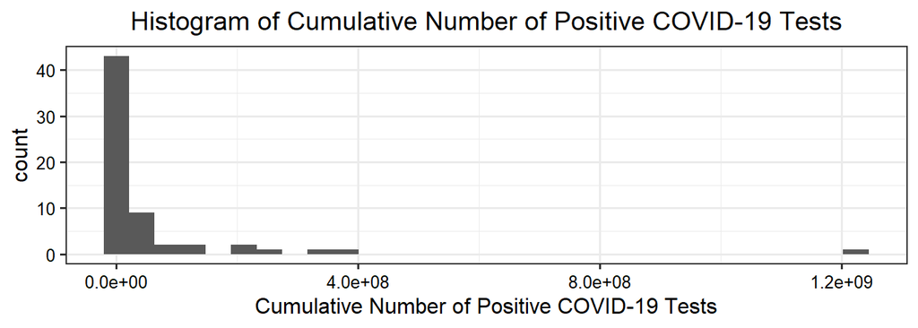

Cumulative Number of Positive COVID-19 Tests

```r
# Visualizing Distribution of Variables

###################### COVID-19 Cases ##############################

ggplot(data = combined_dat_ny_covid_pop, aes(sum_cumulative_no_of_positive))+
  geom_histogram() +
  xlab ("Cumulative Number of Positive COVID-19 Tests") +
  ggtitle("Histogram of Cumulative Number of Positive COVID-19 Tests")
```

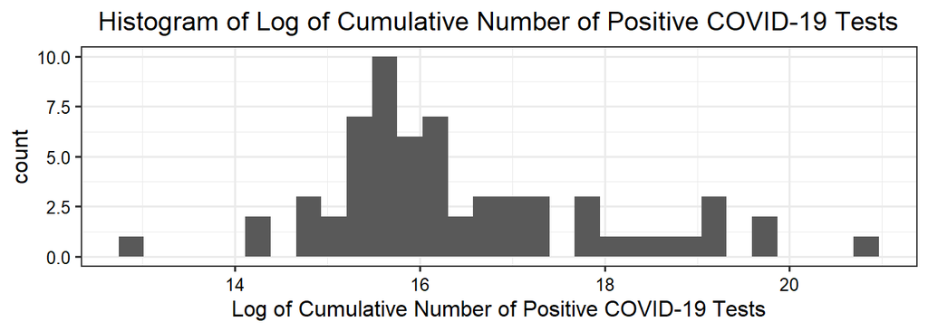

Log of Cumulative Number of Positive COVID-19 Tests

```r
## Log Transform

ggplot(data = combined_dat_ny_covid_pop, aes(log(sum_cumulative_no_of_positive))) +
  geom_histogram() +
  xlab ("Log of Cumulative Number of Positive COVID-19 Tests") +
  ggtitle("Histogram of Log of Cumulative Number of Positive COVID-19 Tests")
```

```r
shapiro.test(log(combined_dat_ny_covid_pop$sum_cumulative_no_of_positive)) #Check normality
```

```
##
##  Shapiro-Wilk normality test
##
## data:  log(combined_dat_ny_covid_pop$sum_cumulative_no_of_positive)
## W = 0.92854, p-value = 0.001407
```

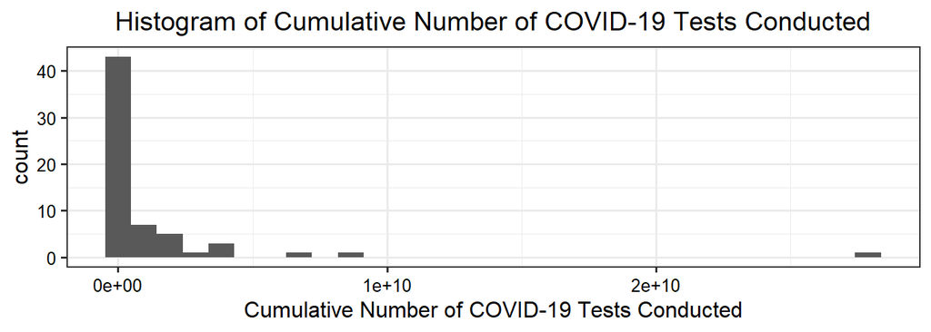

Cumulative Number of COVID-19 Tests Conducted

```r
####################### Number of COVID Tests Conducted #######################

ggplot(data = combined_dat_ny_covid_pop, aes(sum_cumulative_no_of_tests))+
  geom_histogram() +
  xlab ("Cumulative Number of COVID-19 Tests Conducted") +
  ggtitle("Histogram of Cumulative Number of COVID-19 Tests Conducted")
```

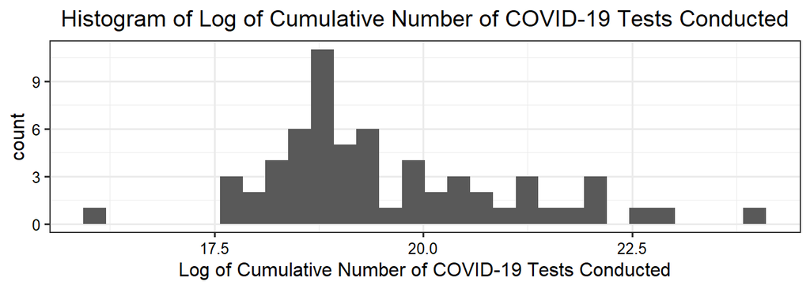

```r
## Log Transform

ggplot(data = combined_dat_ny_covid_pop, aes(log(sum_cumulative_no_of_tests))) +
  geom_histogram() +
  xlab ("Log of Cumulative Number of COVID-19 Tests Conducted") +
  ggtitle("Histogram of Log of Cumulative Number of COVID-19 Tests Conducted")
```

```r
shapiro.test(log(combined_dat_ny_covid_pop$sum_cumulative_no_of_tests)) #Check normality
```

```
##
##  Shapiro-Wilk normality test
##
## data:  log(combined_dat_ny_covid_pop$sum_cumulative_no_of_tests)
## W = 0.94091, p-value = 0.004985
```

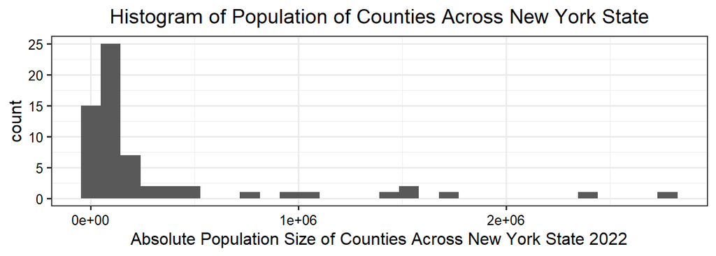

Population of Counties Across New York State

```r
######################### County Population ##########################

ggplot(data = combined_dat_ny_covid_pop, aes(pop2022)) +
  geom_histogram() +
  xlab("Absolute Population Size of Counties Across New York State 2022") +
  ggtitle ("Histogram of Population of Counties Across New York State")
```

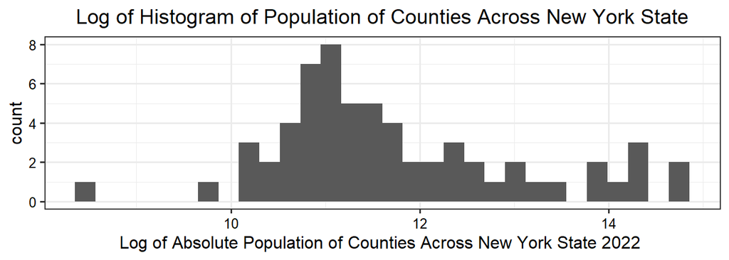

Log of Population of Counties Across New York State

```r
## Log Transform

ggplot(data = combined_dat_ny_covid_pop, aes(log(pop2022))) +
  geom_histogram() +
  xlab("Log of Absolute Population of Counties Across New York State 2022 ") +
  ggtitle ("Log of Histogram of Population of Counties Across New York State")
```

```r
shapiro.test(log(combined_dat_ny_covid_pop$pop2022)) #Check normaliity
```

```
##
##  Shapiro-Wilk normality test
##
## data:  log(combined_dat_ny_covid_pop$pop2022)
## W = 0.93542, p-value = 0.002814
```

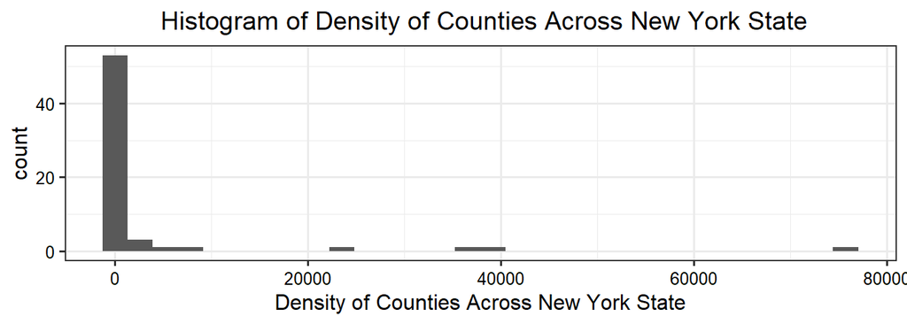

Density of Counties Across New York State

```r
################################## County Density ############################

ggplot(data = combined_dat_ny_covid_pop, aes(density_permilessquared)) +
  geom_histogram() +
  xlab("Density of Counties Across New York State") +
  ggtitle (" Histogram of Density of Counties Across New York State")
```

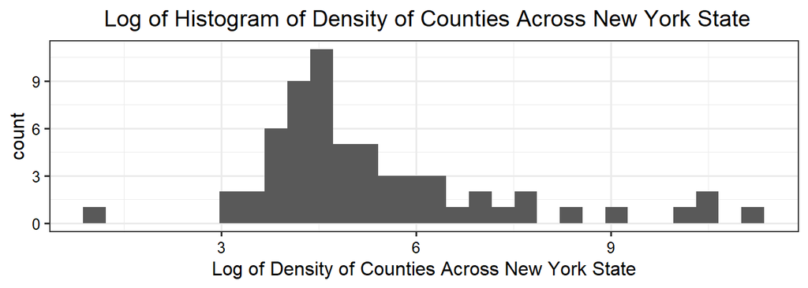

Log of Density of Counties Across New York State

```r
## Log Transform

ggplot(data = combined_dat_ny_covid_pop, aes(log(density_permilessquared))) +
  geom_histogram() +
  xlab("Log of Density of Counties Across New York State") +
  ggtitle (" Log of Histogram of Density of Counties Across New York State")
```

```r
shapiro.test(log(combined_dat_ny_covid_pop$density_permilessquared)) #Check normality
```

```
##
##  Shapiro-Wilk normality test
##
## data:  log(combined_dat_ny_covid_pop$density_permilessquared)
## W = 0.87808, p-value = 1.73e-05
```

[figure not shown]

```r
########### Visualize Distribution of Predictor Variables by Settlement Type

ggplot(data = combined_dat_ny_covid_pop, aes(x= settlement_type, y= log(density_permilessquared), fill = settlement_type))+
  geom_boxplot() +
  ggtitle ("Log of Absolute Population Size of Counties by Settlement Type") +
  xlab("Settlement Types") +
  ylab("Log of Absolute Population Size 2022")
```

[figure not shown]

```r
ggplot(data = combined_dat_ny_covid_pop, aes(x= settlement_type, y= log(pop2022), fill = settlement_type))+
  geom_boxplot() +
    ggtitle ("Log of Population Density of Counties by Settlement Type") +
  xlab("Settlement Types") +
  ylab("Log of Absolute Population Size 2022")
```

### Spatial Context of Data (does not work)

```r
# Read in counties shapefile into an sf dataframe, filtering for just NY counties (GURUBANDAA)

#uscounty <- st_read('./Data/Spatial_Files/cb_2018_us_county_20m.shp', stringsAsFactors = TRUE) %>%
 # filter(
   # STATEFP == 36
   # ) %>%
  #st_as_sf(coords = c('SITE_LONGITUDE','SITE_LATITUDE'), crs=4269)


# Visualize data
#counties.sf <- ggplot(data = uscounty) +
 # geom_sf()

# Plot the data.
#ggplot(data = counties.sf) +
 # geom_sf()

# The EPSG code of the New York counties dataset is 4269. This is a geographic coordinate reference system, so it uses angular coordinate units. This CRS (4269) is associated with the datum NAD83.

# Reveal the names of the columns
#colnames(combined_dat_ny_covid_pop)

# Join the flow data to our NWIS gage location spatial dataframe.
#combined_dat_join <- merge(x = uscounty,
                       #   y = combined_dat_ny_covid_pop,
                        #  by.x = "NAME",
                         # by.y = "County")

# Show the column names of the joined dataset.
#colnames(combined_dat_join)

# Show the dimensions of this joined dataset.
#dim(combined_dat_join)

# Map the population of each New York county in 2022.
#mapview(combined_dat_join,
       # zcol = 'pop2022',
       # col.regions = brewer.pal(2, 'RdBu'))

# Map the settlement types of each New York county in 2022.
#mapview(combined_dat_join,
      #  zcol = 'settlement_type',
       # col.regions = brewer.pal(2, 'RdBu'))

# Map the sum of the cumulative number of tests administered in each New York county in 2022.
#mapview(combined_dat_join,
      #  zcol = 'sum_cumulative_no_of_tests',
       # col.regions = brewer.pal(2, 'RdBu'))

# Map the sum of the cumulative number of positive test results in each New York county in 2022.
#mapview(combined_dat_join,
      #  zcol = 'sum_cumulative_no_of_positive',
      #  col.regions = brewer.pal(2, 'RdBu'))
```

**Export Processed data**

```r
getwd() #Check working directory
```

```
## [1] "C:/Users/sasho/Desktop/Environ Data Analytics/Env872 Workspace/MiltonZouKhalsa__ENV872_EDA_FinalProject"
```

```r
#Full processed data set

write.csv2(combined_dat_ny_covid_pop,"./Data/Processed_Data/Combined_NY_COVID_Pop.csv")

#Collapsed data set

write.csv2(collapsed_dat_settlement_types,"./Data/Processed_Data/collapsed_dat_settlement_types.csv")
```

## Analysis

> As a central question of this study is “How well does population density and absolute population predict COVID-19 cases?”, the predictor variables are population density per miles squared and absolute population while the outcome variable is sum cumulative positive number of positive COVID-19 tests which is being used as a proxy for COVID-19 cases. Our unit of analysis is counties and settlement types depending on the primary objective of each sub-question. Settlement types are classified based on our definitions of rural, micropolitan, and urban settlement types. Our hypotheses for each study question is indicated below.

**Question 1: What is the correlation between population density and absolute population and the number of COVID-19 cases (cumulative number of positive tests) across New York State?**

> Prior to the correlation analysis, the normality of absolute population, population density, and COVID-19 cases were examined and were determined to not be normally distributed (see exploratory analysis). The variables were log-transformed but were showed to still not be normally distributed after a Shapiro-Wilk test of normality was performed. As such, a Spearman correlation analysis for non-parametric data was carried out. The classification of the strength of the relationship was determined based on the value of r which ranges from 0 to 1 where r = 0 indicates no association and r = −1 or +1.

#### Absolute Population and COVID-19 Cases

*Hypotheses*

Null Hypothesis: As the ranks of absolute population change, the ranks of the number of COVID-19 cases do not change.

Alternative Hypothesis: As the ranks of absolute population change, the ranks of the number of COVID-19 cases change.

*Assumptions:*

1. The relationship between both variables is monotonic.

```r
# Spearman rank correlation test as distributions are skewed


correlation_results_absol_pop <- cor.test(x= log(combined_dat_ny_covid_pop$pop2022),
                                          y = log(combined_dat_ny_covid_pop$sum_cumulative_no_of_positive), method = "spearman")
correlation_results_absol_pop
```

```
##
##  Spearman's rank correlation rho
##
## data:  log(combined_dat_ny_covid_pop$pop2022) and log(combined_dat_ny_covid_pop$sum_cumulative_no_of_positive)
## S = 428, p-value < 2.2e-16
## alternative hypothesis: true rho is not equal to 0
## sample estimates:
##       rho
## 0.9892221
```

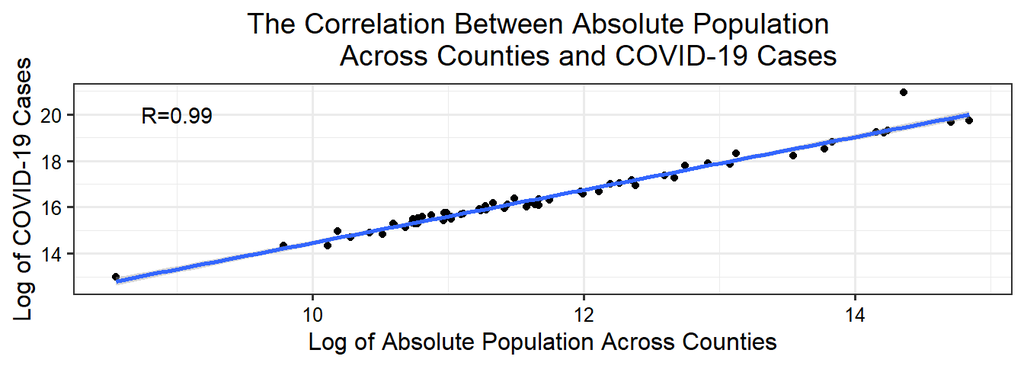

Correlation Between Absolute Population Across Counties and COVID-19 Cases

```r
# Visualize plot (Log-transformed for better visualization)

ggplot(combined_dat_ny_covid_pop, aes(x = log(pop2022), y = log(sum_cumulative_no_of_positive)))+
  geom_point() +
  ylab ("Log of COVID-19 Cases") +
  xlab ("Log of Absolute Population Across Counties") +
  ggtitle ("The Correlation Between Absolute Population
           Across Counties and COVID-19 Cases") +
  stat_smooth (method = 'lm') +
  annotate("text",x=9,y=20, label=(paste0("R=0.99")))
```

### Population Density and COVID-19 Cases

*Hypotheses:*

Null Hypothesis: As the ranks of population density change, the ranks of the number of COVID-19 cases do not change.

Alternative Hypothesis: As the ranks of population density change, the ranks of the number of COVID-19 cases change.

*Assumptions:*

1. The relationship between both variables is monotonic.

```r
# Spearman rank correlation test as distributions are skewed


correlation_results_pop_density <- cor.test(x= log(combined_dat_ny_covid_pop$density_permilessquared),
                                          y = log(combined_dat_ny_covid_pop$sum_cumulative_no_of_positive), method = "spearman")
correlation_results_pop_density
```

```
##
##  Spearman's rank correlation rho
##
## data:  log(combined_dat_ny_covid_pop$density_permilessquared) and log(combined_dat_ny_covid_pop$sum_cumulative_no_of_positive)
## S = 4522, p-value < 2.2e-16
## alternative hypothesis: true rho is not equal to 0
## sample estimates:
##       rho
## 0.8861273
```

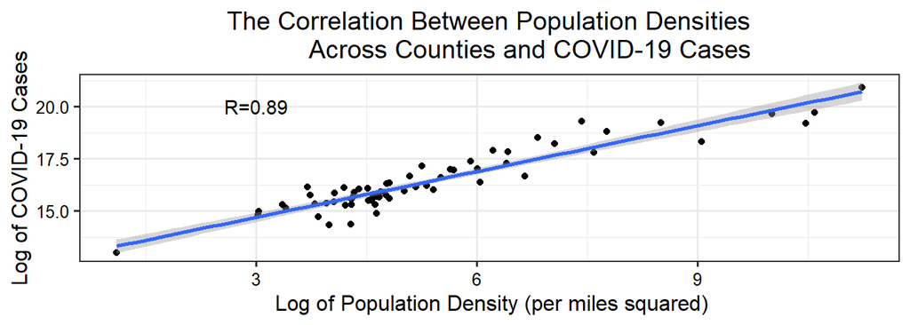

Correlation Between Population Densities Across Counties and COVID-19 Cases

```r
# Visualize plot (Log-transformed for better visualization)

ggplot(combined_dat_ny_covid_pop, aes(x = log(density_permilessquared), y = log(sum_cumulative_no_of_positive)))+
  geom_point() +
  xlab (" Log of Population Density (per miles squared)") +
  ylab ("Log of COVID-19 Cases") +
  ggtitle ("The Correlation Between Population Densities
           Across Counties and COVID-19 Cases") +
  geom_smooth (method = 'lm')+
  annotate("text",x=3,y=20, label=(paste0("R=0.89")))
```

**Question 2: What is the relationship between the predictor variable: settlement types and the response variable: cumulative COVID-19 cases?**

#### Negative Binomial Regression

*Hypotheses:*

Null Hypothesis: There is no trend between the predictor variable (settlement types) and outcome variable (cumulative COVID-19 cases).

Alternative Hypothesis: There is a trend between the response (settlement types) and outcome variables (cumulative COVID-19 cases).

*Assumptions:*

1. The response variable (COVID cases) is a count variable.
2. Each observation of data is independent of each other.
3. The mean and variance are not equal.

```r
## Negative Binomial Regression

summary (modelnb <- glm.nb(sum_cumulative_no_of_positive ~ factor(settlement_type), data = combined_dat_ny_covid_pop))
```

```
##
## Call:
## glm.nb(formula = sum_cumulative_no_of_positive ~ factor(settlement_type),
##     data = combined_dat_ny_covid_pop, init.theta = 0.6722916249,
##     link = log)
##
## Deviance Residuals:
##     Min       1Q   Median       3Q      Max
## -1.5768  -1.2869  -0.6950   0.0667   3.9330
##
## Coefficients:
##                              Estimate Std. Error z value Pr(>|z|)
## (Intercept)                   15.2425     0.3260  46.763  < 2e-16 ***
## factor(settlement_type)Rural  -1.1844     0.7759  -1.526    0.127
## factor(settlement_type)Urban   2.9602     0.3732   7.931 2.17e-15 ***
## ---
## Signif. codes:  0 '***' 0.001 '**' 0.01 '*' 0.05 '.' 0.1 ' ' 1
##
## (Dispersion parameter for Negative Binomial(0.6723) family taken to be 1)
##
##     Null deviance: 122.511  on 61  degrees of freedom
## Residual deviance:  75.366  on 59  degrees of freedom
## AIC: 2273.8
##
## Number of Fisher Scoring iterations: 1
##
##
##               Theta:  0.672
##           Std. Err.:  0.102
##
##  2 x log-likelihood:  -2265.783
```

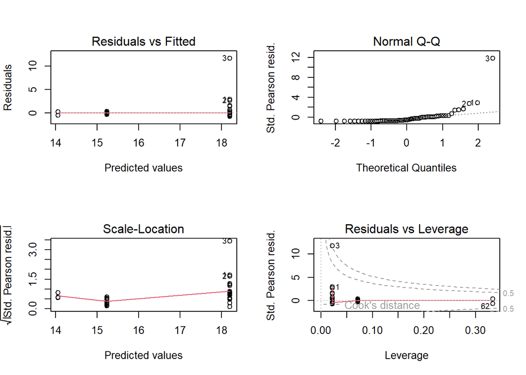

```r
par (mfrow = c(2,2))
plot(modelnb) #Check fit
```

```r
# Test of Fitness

pchisq(q=modelnb$deviance, df=modelnb$df.residual,
lower.tail=FALSE)  #Check model fit
```

```
## [1] 0.0740414
```

```r
## Check our assumption that a negative binomial is a better model than the poisson model

summary (modelpoisson <- glm(sum_cumulative_no_of_positive ~ factor(settlement_type), family = "poisson", data = combined_dat_ny_covid_pop))
```

```
##
## Call:
## glm(formula = sum_cumulative_no_of_positive ~ factor(settlement_type),
##     family = "poisson", data = combined_dat_ny_covid_pop)
##
## Deviance Residuals:
##    Min      1Q  Median      3Q     Max
## -11105  -10010   -5977     168   66186
##
## Coefficients:
##                                Estimate Std. Error z value Pr(>|z|)
## (Intercept)                  15.2424841  0.0001309  116408   <2e-16 ***
## factor(settlement_type)Rural -1.1844175  0.0005279   -2244   <2e-16 ***
## factor(settlement_type)Urban  2.9601778  0.0001320   22427   <2e-16 ***
## ---
## Signif. codes:  0 '***' 0.001 '**' 0.01 '*' 0.05 '.' 0.1 ' ' 1
##
## (Dispersion parameter for poisson family taken to be 1)
##
##     Null deviance: 1.0813e+10  on 61  degrees of freedom
## Residual deviance: 8.9559e+09  on 59  degrees of freedom
## AIC: 8955869537
##
## Number of Fisher Scoring iterations: 6
```

```r
## Summary inference: Residual deviance is much larger than degrees of freedom (DF). Negative binomial plot better.
```

**Question 3: What is the correlation between absolute population and population density and the number of COVID-19 tests done?**

> Similar to question 1, prior to the correlation analysis, the normality of absolute population, population density, and COVID-19 cases were examined and were determined to not be normally distributed (see exploratory analysis). The variables were log-transformed but were showed to still not be normally distributed after a Shapiro-Wilk test of normality was performed. As such, a Spearman correlation analysis for non-parametric data was carried out. The classification of the strength of the relationship was determined based on the value of r which ranges from 0 to 1 where r = 0 indicates no association and r = −1 or +1.

*Hypotheses:*

Null Hypothesis: As the ranks of absolute population change, the ranks of the number of COVID-19 tests conducted do not change.

Alternative Hypothesis: As the ranks of absolute population change, the ranks of the number of COVID-19 tests conducted change.

*Assumptions*

1. The relationship between both variables is monotonic.

```r
# Spearman rank correlation test as distributions are skewed


correlation_results_absol_pop <- cor.test(x= log(combined_dat_ny_covid_pop$pop2022),
                                          y = log(combined_dat_ny_covid_pop$sum_cumulative_no_of_tests), method = "spearman")
correlation_results_absol_pop
```

```
##
##  Spearman's rank correlation rho
##
## data:  log(combined_dat_ny_covid_pop$pop2022) and log(combined_dat_ny_covid_pop$sum_cumulative_no_of_tests)
## S = 996, p-value < 2.2e-16
## alternative hypothesis: true rho is not equal to 0
## sample estimates:
##       rho
## 0.9749188
```

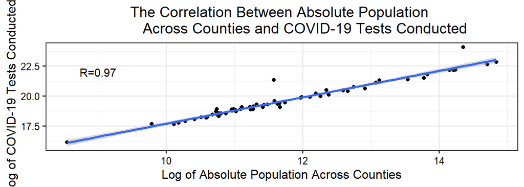

Correlation Between Absolute Population Across Counties and COVID-19 Tests Conducted

```r
# Visualize plot (Log-transformed for better visualization)

ggplot(combined_dat_ny_covid_pop, aes(x = log(pop2022), y = log(sum_cumulative_no_of_tests)))+
  geom_point() +
  ylab ("Log of COVID-19 Tests Conducted") +
  xlab ("Log of Absolute Population Across Counties") +
  ggtitle ("The Correlation Between Absolute Population
           Across Counties and COVID-19 Tests Conducted") +
  stat_smooth (method = 'lm') +
  annotate("text",x=9,y=22, label=(paste0("R=0.97")))
```

*Hypotheses:*

Null Hypothesis: As the ranks of population density change, the ranks of the number of COVID-19 tests conducted do not change.

Alternative Hypothesis: As the ranks of population density change, the ranks of the number of COVID-19 tests conducted change.

*Assumptions:*

1. The relationship between both variables is monotonic.

```r
# Spearman rank correlation test as distributions are skewed


correlation_results_pop_density <- cor.test(x= log(combined_dat_ny_covid_pop$density_permilessquared),
                                          y = log(combined_dat_ny_covid_pop$sum_cumulative_no_of_tests), method = "spearman")
correlation_results_pop_density
```

```
##
##  Spearman's rank correlation rho
##
## data:  log(combined_dat_ny_covid_pop$density_permilessquared) and log(combined_dat_ny_covid_pop$sum_cumulative_no_of_tests)
## S = 5602, p-value < 2.2e-16
## alternative hypothesis: true rho is not equal to 0
## sample estimates:
##       rho
## 0.8589308
```

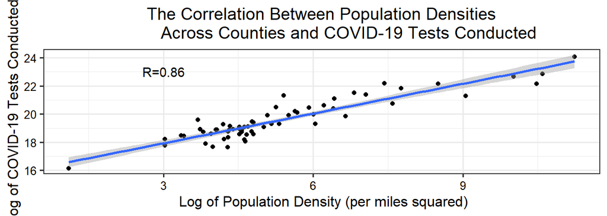

Correlation Between Absolute Population Densities Across Counties and COVID-19 Tests Conducted

```r
# Visualize plot (Log-transformed for better visualization)

ggplot(combined_dat_ny_covid_pop, aes(x = log(density_permilessquared), y = log(sum_cumulative_no_of_tests)))+
  geom_point() +
  xlab (" Log of Population Density (per miles squared)") +
  ylab ("Log of COVID-19 Tests Conducted") +
  ggtitle ("The Correlation Between Population Densities
           Across Counties and COVID-19 Tests Conducted") +
  geom_smooth (method = 'lm')+
  annotate("text",x=3,y=23, label=(paste0("R=0.86")))
```

**Question 3b: Does the stronger correlated relationship vary among settlement types?**

#### Absolute Population and Settlement Types

```r
### Correlation Plots by Settlement Type

##Urban

Urban_dat <- combined_dat_ny_covid_pop %>%
  filter(settlement_type=="Urban")


correlation_results_absolute_pop_urban <- cor.test(x= log(Urban_dat$pop2022),
                                          y = log(Urban_dat$sum_cumulative_no_of_tests), method = "spearman")

correlation_results_absolute_pop_urban
```

```
##
##  Spearman's rank correlation rho
##
## data:  log(Urban_dat$pop2022) and log(Urban_dat$sum_cumulative_no_of_tests)
## S = 632, p-value < 2.2e-16
## alternative hypothesis: true rho is not equal to 0
## sample estimates:
##       rho
## 0.9583663
```

```r
## Micropolitan

Micropolitan_dat <- combined_dat_ny_covid_pop %>%
  filter(settlement_type=="Micropolitan")


correlation_results_absolute_pop_microp <- cor.test(x= log(Micropolitan_dat$pop2022),
                                          y = log(Micropolitan_dat$sum_cumulative_no_of_tests), method = "spearman")

correlation_results_absolute_pop_microp
```

```
##
##  Spearman's rank correlation rho
##
## data:  log(Micropolitan_dat$pop2022) and log(Micropolitan_dat$sum_cumulative_no_of_tests)
## S = 106, p-value = 0.002105
## alternative hypothesis: true rho is not equal to 0
## sample estimates:
##      rho
## 0.767033
```

```r
##Rural

Rural_dat <- combined_dat_ny_covid_pop %>%
  filter(settlement_type=="Rural")


correlation_results_absolute_pop_rural <- cor.test(x= log(Rural_dat$pop2022),
                                          y = log(Rural_dat$sum_cumulative_no_of_tests), method = "spearman")

correlation_results_absolute_pop_rural
```

```
##
##  Spearman's rank correlation rho
##
## data:  log(Rural_dat$pop2022) and log(Rural_dat$sum_cumulative_no_of_tests)
## S = 2, p-value = 1
## alternative hypothesis: true rho is not equal to 0
## sample estimates:
## rho
## 0.5
```

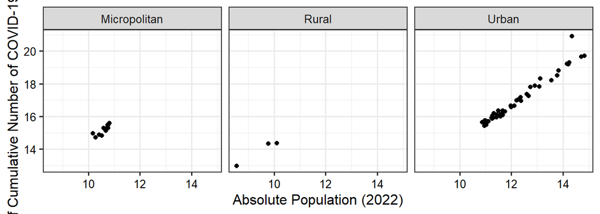

Log of Cumulative COVID-19 Cases Across Settlement Types

```r
ggplot(combined_dat_ny_covid_pop, aes(x = log(pop2022), y = log(sum_cumulative_no_of_positive)))+
  geom_point() +
  ylab ("Log of Cumulative Number of COVID-19 Cases") +
  xlab ("Absolute Population (2022)")+
  facet_wrap(vars(settlement_type))
```

## Summary and Conclusions

#### General Overview of Data

> The most populous county in New York State according to the information we obtained from the US Census Bureau is Kings County which has a population of over 2.7 million people. Meanwhile, the least populous county was Hamilton county with a little over 5000 residents. Despite Kings County have the most residents in the state, New York City was the most densely populated county - with 75,739 residents per squared miles. In addition to being the least populated county, Hamilton was the least dense of the 62 counties in New York State.

## Conclusion

> In conclusion, we do see a strong correlation between both absolute population and population density and the number of COVID-19 cases in New York, as well as the relationship between both absolute population and population density and the number of COVID-19 tests conducted in New York. In both cases, the absolute population correlation was the stronger of the two. There is also a strong correlation between absolute population and urban settlements.

## References

1. CDC. (2020, February 11). COVID-19 and Your Health. Centers for Disease Control and Prevention. https://www.cdc.gov/coronavirus/2019-ncov/your-health/reinfection.html
2. CDCMMWR. (2020). Geographic Differences in COVID-19 Cases, Deaths, and Incidence—United States, February 12–April 7, 2020. MMWR. Morbidity and Mortality Weekly Report, 69. https://doi.org/10.15585/mmwr.mm6915e4
3. Coronavirus. (n.d.). Retrieved March 14, 2022, from https://www.who.int/westernpacific/health-topics/coronavirus
4. Hamidi, S., Sabouri, S., & Ewing, R. (2020). Does Density Aggravate the COVID-19 Pandemic? Journal of the American Planning Association, 86(4), 495–509. https://doi.org/10.1080/01944363.2020.1777891
5. New York Population 2022 (Demographics, Maps, Graphs). (n.d.). Retrieved December 10, 2022, from https://worldpopulationreview.com/states/new-york-population
6. New York State Tracking Program | Tracking | NCEH | CDC. (2019, February 20). https://www.cdc.gov/nceh/tracking/profiles/New_York_State_Profile.htm
7. Settlements Overview & Types | What are Settlements? - Video & Lesson Transcript. (n.d.). Study.Com. Retrieved December 10, 2022, from https://study.com/learn/lesson/settlements-overview-types.html
8. Times, T. N. Y. (2020, April 1). New York Coronavirus Map and Case Count. The New York Times. https://www.nytimes.com/interactive/2021/us/new-york-covid-cases.html
9. Truelove, S., Smith, C. P., Qin, M., Mullany, L. C., Borchering, R. K., Lessler, J., Shea, K., Howerton, E., Contamin, L., Levander, J., Kerr, J., Hochheiser, H., Kinsey, M., Tallaksen, K., Wilson, S., Shin, L., Rainwater-Lovett, K., Lemairtre, J.
10. C., Dent, J., … Viboud, C. (n.d.). Projected resurgence of COVID-19 in the United States in July—December 2021 resulting from the increased transmissibility of the Delta variant and faltering vaccination. ELife, 11, e73584. https://doi.org/10.7554/eLife.73584
11. USDA ERS - What is Rural? (n.d.). Retrieved November 27, 2022, from https://www.ers.usda.gov/topics/rural-economy-population/rural-classifications/what-is-rural.aspx
12. What Is Coronavirus? (2022, July 29). https://www.hopkinsmedicine.org/health/conditions-and-diseases/coronavirus
13. Wong, D. W. S., & Li, Y. (2020). Spreading of COVID-19: Density matters. PLOS ONE, 15(12), e0242398. https://doi.org/10.1371/journal.pone.0242398